# Part-A: Solution

# Part-B: Solution

- **DOMAIN:** Autonomous Vehicles
- **CONTEXT:**
- A Recognising multi-digit numbers in photographs captured at street level is an important component of modern-day map making. A classic example of a corpus of such street-level photographs is Google’s Street View imagery composed of hundreds of millions of geo-located 360-degree panoramic images.
- The ability to automatically transcribe an address number from a geo-located patch of pixels and associate the transcribed number with a known street address helps pinpoint, with a high degree of accuracy, the location of the building it represents. More broadly, recognising numbers in photographs is a problem of interest to the optical character recognition community.
- While OCR on constrained domains like document processing is well studied, arbitrary multi-character text recognition in photographs is still highly challenging. This difficulty arises due to the wide variability in the visual appearance of text in the wild on account of a large range of fonts, colours, styles, orientations, and character arrangements.
- The recognition problem is further complicated by environmental factors such as lighting, shadows, specularity, and occlusions as well as by image acquisition factors such as resolution, motion, and focus blurs. In this project, we will use the dataset with images centred around a single digit (many of the images do contain some distractors at the sides). Although we are taking a sample of the data which is simpler, it is more complex than MNIST because of the distractors.
- **DATA DESCRIPTION:**
- The SVHN is a real-world image dataset for developing machine learning and object recognition algorithms with the minimal requirement on data formatting but comes from a significantly harder, unsolved, real-world problem (recognising digits and numbers in natural scene images). SVHN is obtained from house numbers in Google Street View images.

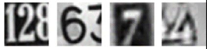

- Where the labels for each of this image are the prominent number in that image i.e. 2,6,7 and 4 respectively.
- The dataset has been provided in the form of h5py files. You can read about this file format here: https://docs.h5py.org/en/stable/
- Acknowledgement: Yuval Netzer, Tao Wang, Adam Coates, Alessandro Bissacco, Bo Wu, Andrew Y. Ng Reading Digits in Natural Images with Unsupervised
- Feature Learning NIPS Workshop on Deep Learning and Unsupervised Feature Learning 2011. PDF

http://ufldl.stanford.edu/housenumbers as the URL for this site.

- **PROJECT OBJECTIVE:** To build a digit classifier on the SVHN (Street View Housing Number) dataset.

```python
# Import all the relevant libraries needed to complete the analysis, visualization, modeling and presentation
import pandas as pd
import numpy as np
import os

import seaborn as sns
import matplotlib.pyplot as plt
%matplotlib inline
sns.set_style('darkgrid')
%matplotlib inline

from scipy import stats
from scipy.stats import zscore

from sklearn.preprocessing import LabelEncoder
from sklearn.preprocessing import StandardScaler
from sklearn.preprocessing import MinMaxScaler
from sklearn.preprocessing import RobustScaler
from sklearn import model_selection
from sklearn.model_selection import train_test_split, cross_val_score, GridSearchCV
from sklearn.model_selection import RandomizedSearchCV, StratifiedKFold, KFold
from sklearn.metrics import accuracy_score, confusion_matrix, classification_report
from sklearn.metrics import ConfusionMatrixDisplay, precision_score, recall_score
from sklearn.metrics import precision_recall_curve, roc_curve, auc, roc_auc_score
from sklearn.metrics import plot_precision_recall_curve, average_precision_score
from sklearn.metrics import f1_score, plot_roc_curve

from imblearn.over_sampling import RandomOverSampler
from imblearn.over_sampling import SMOTENC, SMOTE, ADASYN
from imblearn.under_sampling import RandomUnderSampler

import warnings
warnings.filterwarnings("ignore")

# pd.set_option('display.max_columns', None)
# pd.set_option('display.max_rows', None)
```

```python
# Load the Drive helper and mount
from google.colab import drive

# This will prompt for authorization.
drive.mount('/content/drive')
```

## 1. Data Import and Exploration:

### 1A. Read the .h5 file and assign to a variable.

```python
# Read the data
# h5py package: a Python interface to the HDF5 scientific data format.
import h5py
df = h5py.File('/content/drive/MyDrive/MGL/Project-DL/Autonomous_Vehicles_SVHN_single_grey1.h5', 'r')
```

### 1B. Print all the keys from the .h5 file.

```python
df.keys()
```

```
<KeysViewHDF5 ['X_test', 'X_train', 'X_val', 'y_test', 'y_train', 'y_val']>
```

### 1C. Split the data into X_train, X_test, y_train, y_test.

```python
X_train = df['X_train'][:]
X_test = df['X_test'][:]

y_train = df['y_train'][:]
y_test = df['y_test'][:]

# X_val = df['X_val'][:]
# y_val = df['y_val'][:]
```

Check the contents of features and labels of one example from the dataset

```python
X_train[:1]
```

```
array([[[ 33.0704,  30.2601,  26.852 , ...,  71.4471,  58.2204,
          42.9939],
        [ 25.2283,  25.5533,  29.9765, ..., 113.0209, 103.3639,
          84.2949],
        [ 26.2775,  22.6137,  40.4763, ..., 113.3028, 121.775 ,
         115.4228],
        ...,
        [ 28.5502,  36.212 ,  45.0801, ...,  24.1359,  25.0927,
          26.0603],
        [ 38.4352,  26.4733,  23.2717, ...,  28.1094,  29.4683,
          30.0661],
        [ 50.2984,  26.0773,  24.0389, ...,  49.6682,  50.853 ,
          53.0377]]], dtype=float32)
```

```python
X_test[:1]
```

```
array([[[ 40.558 ,  46.7917,  48.9764, ..., 112.1153, 112.9904,
         112.1646],
        [ 39.4379,  44.2911,  47.1768, ..., 111.0122, 110.9475,
         109.9368],
        [ 38.4488,  43.6394,  48.7098, ..., 109.8921, 109.9414,
         109.1048],
        ...,
        [ 34.9869,  35.4707,  39.6676, ..., 109.211 , 109.9074,
         112.7346],
        [ 35.6602,  35.5462,  40.3193, ..., 110.9998, 112.049 ,
         114.3431],
        [ 36.1871,  35.4214,  40.6998, ..., 110.0169, 111.2017,
         114.1906]]], dtype=float32)
```

```python
y_train[:1]
```

```
array([2], dtype=uint8)
```

```python
y_test[:1]
```

```
array([1], dtype=uint8)
```

## 2. Data Visualisation and preprocessing:

### 2A. Print shape of all the 4 data split into x, y, train, test to verify if x & y is in sync.

```python
print(X_train.shape,X_test.shape)
print(y_train.shape,y_test.shape)

# print(X_val.shape,y_val.shape)
```

```
(42000, 32, 32) (18000, 32, 32)
(42000,) (18000,)
```

### 2B. Visualise first 10 images in train data and print its corresponding labels.

```
Label for each of the above images: [2 6 7 4 4 0 3 0 7 3]
```

```python
# Label of the most prominent number in image
plt.figure(figsize=(10, 2))
for i in range(10):
    plt.subplot(1, 10, i+1)
    plt.imshow(X_train[i], cmap="gray")
    plt.axis('off')
plt.show()

print('Label for each of the above images: %s' % (y_train[0:10]))
```

[output not shown]

### 2C. Reshape all the images with appropriate shape update the data in same variable.

```python
# Need to reshape the X_train and X_test so that the same can be fed for model building.
# Currently we have a 3D tensor and we need to feed a 2D tensor into the model.

X_train = X_train.reshape(X_train.shape[0], 1024, 1)
X_test = X_test.reshape(X_test.shape[0], 1024, 1)

print('Resized Training set', X_train.shape, y_train.shape)
print('Resized Test set', X_test.shape, y_test.shape)
```

```
Resized Training set (42000, 1024, 1) (42000,)
Resized Test set (18000, 1024, 1) (18000,)
```

### 2D. Normalise the images i.e. Normalise the pixel values.

```python
# To normalize the data; We can divide it by 255 (Grayscale image can take values from 0-255)
# Normalize inputs from 0-255 to 0-1 range
X_train = X_train / 255.0
X_test = X_test / 255.0
```

### 2E. Transform Labels into format acceptable by Neural Network.

```python
# Encoding is used for categorical data
# We can consider 1 to 10 as categorical
# Use one hot encoding
y_train = pd.get_dummies(y_train)
y_test = pd.get_dummies(y_test)
```

```python
y_train.head()
```

|  | 0 | 1 | 2 | 3 | 4 | 5 | 6 | 7 | 8 | 9 |
| --- | --- | --- | --- | --- | --- | --- | --- | --- | --- | --- |
| 0 | 0 | 0 | 1 | 0 | 0 | 0 | 0 | 0 | 0 | 0 |
| 1 | 0 | 0 | 0 | 0 | 0 | 0 | 1 | 0 | 0 | 0 |
| 2 | 0 | 0 | 0 | 0 | 0 | 0 | 0 | 1 | 0 | 0 |
| 3 | 0 | 0 | 0 | 0 | 1 | 0 | 0 | 0 | 0 | 0 |
| 4 | 0 | 0 | 0 | 0 | 1 | 0 | 0 | 0 | 0 | 0 |

```python
y_test.head()
```

|  | 0 | 1 | 2 | 3 | 4 | 5 | 6 | 7 | 8 | 9 |
| --- | --- | --- | --- | --- | --- | --- | --- | --- | --- | --- |
| 0 | 0 | 1 | 0 | 0 | 0 | 0 | 0 | 0 | 0 | 0 |
| 1 | 0 | 0 | 0 | 0 | 0 | 0 | 0 | 1 | 0 | 0 |
| 2 | 0 | 0 | 1 | 0 | 0 | 0 | 0 | 0 | 0 | 0 |
| 3 | 0 | 0 | 0 | 0 | 0 | 0 | 0 | 0 | 0 | 1 |
| 4 | 1 | 0 | 0 | 0 | 0 | 0 | 0 | 0 | 0 | 0 |

```python
# Final dataset shape
print(X_train.shape,X_test.shape)
print(y_train.shape,y_test.shape)
```

```
(42000, 1024, 1) (18000, 1024, 1)
(42000, 10) (18000, 10)
```

### 2F. Print total Number of classes in the Dataset.

```python
num_classes = y_test.shape[1]
print("The number of classes in this dataset are:",num_classes)
```

```
The number of classes in this dataset are: 10
```

## 3. Model Training & Evaluation using Neural Network

- 3A. Design a Neural Network to train a classifier.
- 3B. Train the classifier using previously designed Architecture (Use best suitable parameters).
- 3C. Evaluate performance of the model with appropriate metrics.
- 3D. Plot the training loss, validation loss vs number of epochs and training accuracy, validation accuracy vs number of epochs plot and write your observations on the same.

### Model-1: Base Model

```python
# Define model1
import keras
from tensorflow.keras import losses
from tensorflow.keras import optimizers
from tensorflow.keras import Sequential
from tensorflow.keras.layers import Dense

# create model1
model1 = Sequential()
# Multiple Dense units with Relu activation
model1.add(Dense(256, activation='relu',kernel_initializer='he_uniform', input_dim = X_train.shape[1]))
model1.add(Dense(64, activation='relu',kernel_initializer='he_uniform'))
model1.add(Dense(64, activation='relu',kernel_initializer='he_uniform'))
model1.add(Dense(32, activation='relu',kernel_initializer='he_uniform'))
# For multiclass classification Softmax is used
model1.add(Dense(num_classes, activation='softmax'))
```

```python
# Compile model1
# RMS_prop=optimizers.RMSprop()
# We can similarly use different optimizers like RMSprop, Adagrad and SGD
# Loss function = Categorical cross entropy
adam = optimizers.Adam(lr=1e-3)
model1.compile(loss=losses.categorical_crossentropy, optimizer=adam, metrics=['accuracy'])
```

```python
# Looking into our base model1
model1.summary()
```

```
Model: "sequential"
_________________________________________________________________
 Layer (type)                Output Shape              Param #
=================================================================
 dense (Dense)               (None, 256)               262400

 dense_1 (Dense)             (None, 64)                16448

 dense_2 (Dense)             (None, 64)                4160

 dense_3 (Dense)             (None, 32)                2080

 dense_4 (Dense)             (None, 10)                330

=================================================================
Total params: 285,418
Trainable params: 285,418
Non-trainable params: 0
_________________________________________________________________
```

```python
# Fit the model1
history1=model1.fit(X_train, y_train, validation_split=0.2, epochs=100, batch_size=200, verbose=2)
```

```
168/168 - 2s - loss: 2.2516 - accuracy: 0.1480 - val_loss: 2.0290 - val_accuracy: 0.2708 - 2s/epoch - 13ms/step
168/168 - 2s - loss: 1.7922 - accuracy: 0.3756 - val_loss: 1.5108 - val_accuracy: 0.5088 - 2s/epoch - 11ms/step
168/168 - 2s - loss: 1.4381 - accuracy: 0.5268 - val_loss: 1.3578 - val_accuracy: 0.5646 - 2s/epoch - 12ms/step
168/168 - 2s - loss: 1.3009 - accuracy: 0.5797 - val_loss: 1.2740 - val_accuracy: 0.5920 - 2s/epoch - 12ms/step
168/168 - 2s - loss: 1.1985 - accuracy: 0.6207 - val_loss: 1.2476 - val_accuracy: 0.6038 - 2s/epoch - 11ms/step
168/168 - 2s - loss: 1.1277 - accuracy: 0.6478 - val_loss: 1.1020 - val_accuracy: 0.6602 - 2s/epoch - 10ms/step
168/168 - 2s - loss: 1.0980 - accuracy: 0.6580 - val_loss: 1.1180 - val_accuracy: 0.6517 - 2s/epoch - 9ms/step
168/168 - 1s - loss: 1.0371 - accuracy: 0.6786 - val_loss: 1.0546 - val_accuracy: 0.6695 - 1s/epoch - 7ms/step
168/168 - 1s - loss: 0.9902 - accuracy: 0.6947 - val_loss: 0.9954 - val_accuracy: 0.6917 - 1s/epoch - 6ms/step
168/168 - 1s - loss: 0.9641 - accuracy: 0.7016 - val_loss: 1.0506 - val_accuracy: 0.6762 - 1s/epoch - 7ms/step
168/168 - 1s - loss: 0.9309 - accuracy: 0.7143 - val_loss: 0.9481 - val_accuracy: 0.7060 - 1s/epoch - 6ms/step
168/168 - 1s - loss: 0.9153 - accuracy: 0.7172 - val_loss: 0.9360 - val_accuracy: 0.7126 - 1s/epoch - 6ms/step
168/168 - 1s - loss: 0.8754 - accuracy: 0.7310 - val_loss: 0.9222 - val_accuracy: 0.7194 - 1s/epoch - 6ms/step
168/168 - 1s - loss: 0.8684 - accuracy: 0.7322 - val_loss: 0.9127 - val_accuracy: 0.7163 - 1s/epoch - 7ms/step
168/168 - 1s - loss: 0.8347 - accuracy: 0.7446 - val_loss: 0.9169 - val_accuracy: 0.7140 - 1s/epoch - 6ms/step
168/168 - 1s - loss: 0.8190 - accuracy: 0.7469 - val_loss: 0.8499 - val_accuracy: 0.7375 - 1s/epoch - 6ms/step
168/168 - 1s - loss: 0.8035 - accuracy: 0.7524 - val_loss: 0.8634 - val_accuracy: 0.7342 - 1s/epoch - 7ms/step
168/168 - 1s - loss: 0.7829 - accuracy: 0.7565 - val_loss: 0.8481 - val_accuracy: 0.7395 - 1s/epoch - 6ms/step
168/168 - 1s - loss: 0.7706 - accuracy: 0.7604 - val_loss: 0.8657 - val_accuracy: 0.7306 - 1s/epoch - 6ms/step
168/168 - 1s - loss: 0.7732 - accuracy: 0.7590 - val_loss: 0.8017 - val_accuracy: 0.7524 - 1s/epoch - 6ms/step
168/168 - 1s - loss: 0.7468 - accuracy: 0.7685 - val_loss: 0.8183 - val_accuracy: 0.7532 - 1s/epoch - 7ms/step
168/168 - 1s - loss: 0.7327 - accuracy: 0.7726 - val_loss: 0.7976 - val_accuracy: 0.7606 - 1s/epoch - 7ms/step
168/168 - 1s - loss: 0.7214 - accuracy: 0.7770 - val_loss: 0.7875 - val_accuracy: 0.7600 - 1s/epoch - 7ms/step
168/168 - 1s - loss: 0.7048 - accuracy: 0.7804 - val_loss: 0.8091 - val_accuracy: 0.7555 - 1s/epoch - 7ms/step
168/168 - 1s - loss: 0.7010 - accuracy: 0.7852 - val_loss: 0.7463 - val_accuracy: 0.7788 - 1s/epoch - 7ms/step
168/168 - 1s - loss: 0.6994 - accuracy: 0.7812 - val_loss: 0.7990 - val_accuracy: 0.7544 - 1s/epoch - 7ms/step
168/168 - 1s - loss: 0.6851 - accuracy: 0.7877 - val_loss: 0.7802 - val_accuracy: 0.7614 - 1s/epoch - 6ms/step
168/168 - 1s - loss: 0.6664 - accuracy: 0.7915 - val_loss: 0.7848 - val_accuracy: 0.7625 - 1s/epoch - 7ms/step
168/168 - 2s - loss: 0.6651 - accuracy: 0.7915 - val_loss: 0.7538 - val_accuracy: 0.7707 - 2s/epoch - 10ms/step
168/168 - 2s - loss: 0.6477 - accuracy: 0.7993 - val_loss: 0.7683 - val_accuracy: 0.7658 - 2s/epoch - 12ms/step
168/168 - 1s - loss: 0.6378 - accuracy: 0.8000 - val_loss: 0.7612 - val_accuracy: 0.7720 - 1s/epoch - 6ms/step
168/168 - 1s - loss: 0.6319 - accuracy: 0.8026 - val_loss: 0.7240 - val_accuracy: 0.7880 - 1s/epoch - 6ms/step
168/168 - 1s - loss: 0.6173 - accuracy: 0.8069 - val_loss: 0.7281 - val_accuracy: 0.7821 - 1s/epoch - 7ms/step
168/168 - 1s - loss: 0.6234 - accuracy: 0.8077 - val_loss: 0.7184 - val_accuracy: 0.7871 - 1s/epoch - 6ms/step
168/168 - 1s - loss: 0.6172 - accuracy: 0.8070 - val_loss: 0.7154 - val_accuracy: 0.7894 - 1s/epoch - 6ms/step
168/168 - 1s - loss: 0.6075 - accuracy: 0.8104 - val_loss: 0.7009 - val_accuracy: 0.7892 - 1s/epoch - 6ms/step
168/168 - 1s - loss: 0.5947 - accuracy: 0.8138 - val_loss: 0.7280 - val_accuracy: 0.7862 - 1s/epoch - 7ms/step
168/168 - 1s - loss: 0.5966 - accuracy: 0.8157 - val_loss: 0.7117 - val_accuracy: 0.7915 - 1s/epoch - 6ms/step
168/168 - 1s - loss: 0.5910 - accuracy: 0.8159 - val_loss: 0.7258 - val_accuracy: 0.7851 - 1s/epoch - 7ms/step
168/168 - 1s - loss: 0.5810 - accuracy: 0.8163 - val_loss: 0.7446 - val_accuracy: 0.7821 - 1s/epoch - 7ms/step
```

[output cut: 45 more lines]

```
168/168 - 1s - loss: 0.4260 - accuracy: 0.8630 - val_loss: 0.7134 - val_accuracy: 0.8011 - 1s/epoch - 6ms/step
168/168 - 1s - loss: 0.4141 - accuracy: 0.8677 - val_loss: 0.7222 - val_accuracy: 0.8020 - 1s/epoch - 6ms/step
168/168 - 1s - loss: 0.4082 - accuracy: 0.8693 - val_loss: 0.7250 - val_accuracy: 0.8060 - 1s/epoch - 6ms/step
168/168 - 1s - loss: 0.4181 - accuracy: 0.8655 - val_loss: 0.7520 - val_accuracy: 0.7962 - 958ms/epoch - 6ms/step
168/168 - 1s - loss: 0.4013 - accuracy: 0.8712 - val_loss: 0.7001 - val_accuracy: 0.8126 - 1s/epoch - 6ms/step
168/168 - 1s - loss: 0.3964 - accuracy: 0.8731 - val_loss: 0.7142 - val_accuracy: 0.8083 - 1s/epoch - 6ms/step
168/168 - 1s - loss: 0.3912 - accuracy: 0.8739 - val_loss: 0.7283 - val_accuracy: 0.8008 - 1s/epoch - 6ms/step
168/168 - 1s - loss: 0.3954 - accuracy: 0.8734 - val_loss: 0.7198 - val_accuracy: 0.8131 - 1s/epoch - 7ms/step
168/168 - 1s - loss: 0.3970 - accuracy: 0.8717 - val_loss: 0.7234 - val_accuracy: 0.8043 - 1s/epoch - 7ms/step
168/168 - 1s - loss: 0.3961 - accuracy: 0.8734 - val_loss: 0.7112 - val_accuracy: 0.8073 - 1s/epoch - 7ms/step
168/168 - 1s - loss: 0.3956 - accuracy: 0.8729 - val_loss: 0.7420 - val_accuracy: 0.8064 - 1s/epoch - 7ms/step
168/168 - 1s - loss: 0.3912 - accuracy: 0.8742 - val_loss: 0.7286 - val_accuracy: 0.8052 - 1s/epoch - 6ms/step
168/168 - 1s - loss: 0.3998 - accuracy: 0.8699 - val_loss: 0.7392 - val_accuracy: 0.8036 - 1s/epoch - 6ms/step
168/168 - 1s - loss: 0.3964 - accuracy: 0.8702 - val_loss: 0.7326 - val_accuracy: 0.8087 - 1s/epoch - 7ms/step
168/168 - 1s - loss: 0.3812 - accuracy: 0.8751 - val_loss: 0.7274 - val_accuracy: 0.8061 - 1s/epoch - 7ms/step
```

```python
# predicting the model1 on test data
y_pred=model1.predict(X_test)
```

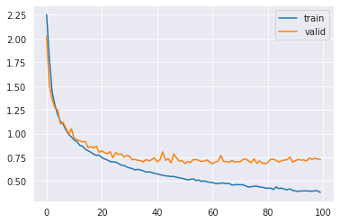

```python
# Capturing learning history per epoch
hist  = pd.DataFrame(history1.history)
hist['epoch'] = history1.epoch

# Plotting accuracy at different epochs
plt.plot(hist['loss'])
plt.plot(hist['val_loss'])
plt.legend(("train" , "valid") , loc =0)

# Printing results
results = model1.evaluate(X_test, y_test)
```

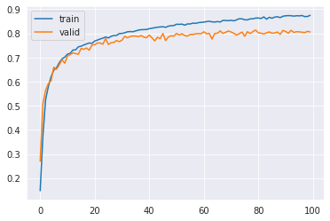

```python
# Capturing learning history per epoch
hist  = pd.DataFrame(history1.history)
hist['epoch'] = history1.epoch

# Plotting accuracy at different epochs
plt.plot(hist['accuracy'])
plt.plot(hist['val_accuracy'])
plt.legend(("train" , "valid") , loc =0)

# Printing results
results = model1.evaluate(X_test, y_test)
```

```
Loss and Accuracy on Training data: [0.42733943462371826, 0.8710476160049438]
Loss and Accuracy on Test data: [0.7382670640945435, 0.8072777986526489]

Classification Report:
               precision    recall  f1-score   support

           0       0.88      0.82      0.85      1814
           1       0.80      0.84      0.82      1828
           2       0.78      0.83      0.81      1803
           3       0.75      0.77      0.76      1719
           4       0.89      0.82      0.85      1812
           5       0.78      0.80      0.79      1768
           6       0.78      0.82      0.80      1832
           7       0.89      0.80      0.84      1808
           8       0.75      0.78      0.76      1812
           9       0.80      0.79      0.80      1804

    accuracy                           0.81     18000
   macro avg       0.81      0.81      0.81     18000
weighted avg       0.81      0.81      0.81     18000

Confusion Matrix Chart:
```

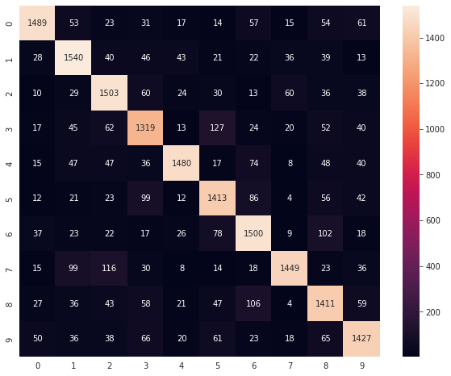

```python
# Classification Accuracy
print('Loss and Accuracy on Training data:',model1.evaluate(X_train, y_train))
print('Loss and Accuracy on Test data:',model1.evaluate(X_test, y_test))
print()

# Classification Report
print("Classification Report:\n",classification_report(y_test.values.argmax(axis=1), y_pred.argmax(axis=1)))

# Confusion Matrix
print("Confusion Matrix Chart:")
cm = confusion_matrix(y_test.values.argmax(axis=1), y_pred.argmax(axis=1), labels=[0,1,2,3,4,5,6,7,8,9])
df_cm = pd.DataFrame(cm, index = [i for i in ['0','1','2','3','4','5','6','7','8','9']],
                  columns = [i for i in ['0','1','2','3','4','5','6','7','8','9']])
plt.figure(figsize = (10,8))
sns.heatmap(df_cm, annot=True, fmt='g')
plt.show()
```

**Evaluation metrics allow us to estimate errors to determine how well our models are performing:**

> Accuracy: ratio of correct predictions over total predictions.

> Precision: how often the classifier is correct when it predicts positive.

> Recall: how often the classifier is correct for all positive instances.

> F-Score: single measurement to combine precision and recall.

**Considering the Class Recall, Precision, F1 Score and Accuracy as the most important parameters to decide the best model for this problem. We have the highest values in Model-3. Please refer the Model-3 for the same.**

### Model-2: Improving the Base Model

Using Dropout and Batch Normalization

```python
# Define model2

from tensorflow.keras import losses
from tensorflow.keras import optimizers
from tensorflow.keras import Sequential
from tensorflow.keras.layers import Dense

from tensorflow.keras.layers import BatchNormalization
from tensorflow.keras.layers import Dropout

# create model2
model2 = Sequential()
# Multiple Dense units with Relu activation
model2.add(Dense(256, activation='relu',kernel_initializer='he_uniform',input_dim=X_train.shape[1]))
model2.add(Dense(64, activation='relu',kernel_initializer='he_uniform'))
model2.add(Dense(64, activation='relu',kernel_initializer='he_uniform'))
model2.add(Dense(32, activation='relu',kernel_initializer='he_uniform'))

model2.add(Dropout(0.5))
model2.add(BatchNormalization())
# For multiclass classification Softmax is used
model2.add(Dense(num_classes, activation='softmax'))
```

```python
# Compile model2
# RMS_prop=optimizers.RMSprop()
# We can similarly use different optimizers like RMSprop, Adagrad and SGD
# Loss function = Categorical cross entropy
adam = optimizers.Adam(lr=1e-3)
model2.compile(loss=losses.categorical_crossentropy, optimizer=adam, metrics=['accuracy'])
```

```python
# Looking into our base model2
model2.summary()
```

```
Model: "sequential_1"
_________________________________________________________________
 Layer (type)                Output Shape              Param #
=================================================================
 dense_5 (Dense)             (None, 256)               262400

 dense_6 (Dense)             (None, 64)                16448

 dense_7 (Dense)             (None, 64)                4160

 dense_8 (Dense)             (None, 32)                2080

 dropout (Dropout)           (None, 32)                0

 batch_normalization (BatchN  (None, 32)               128
 ormalization)

 dense_9 (Dense)             (None, 10)                330

=================================================================
Total params: 285,546
Trainable params: 285,482
Non-trainable params: 64
_________________________________________________________________
```

```python
# Fit the model2
history2=model2.fit(X_train, y_train, validation_split=0.2, epochs=100, batch_size=200, verbose=2)
```

```
168/168 - 2s - loss: 2.4151 - accuracy: 0.1012 - val_loss: 2.3366 - val_accuracy: 0.1054 - 2s/epoch - 11ms/step
168/168 - 1s - loss: 2.3314 - accuracy: 0.1004 - val_loss: 2.3046 - val_accuracy: 0.0998 - 1s/epoch - 7ms/step
168/168 - 1s - loss: 2.3106 - accuracy: 0.1009 - val_loss: 2.3032 - val_accuracy: 0.0996 - 1s/epoch - 6ms/step
168/168 - 1s - loss: 2.3058 - accuracy: 0.1013 - val_loss: 2.3029 - val_accuracy: 0.0983 - 1s/epoch - 8ms/step
168/168 - 1s - loss: 2.3032 - accuracy: 0.1008 - val_loss: 2.3031 - val_accuracy: 0.0957 - 1s/epoch - 7ms/step
168/168 - 1s - loss: 2.3030 - accuracy: 0.0999 - val_loss: 2.3029 - val_accuracy: 0.0954 - 1s/epoch - 6ms/step
168/168 - 1s - loss: 2.3026 - accuracy: 0.1051 - val_loss: 2.3031 - val_accuracy: 0.0975 - 1s/epoch - 7ms/step
168/168 - 1s - loss: 2.3028 - accuracy: 0.1019 - val_loss: 2.3030 - val_accuracy: 0.0950 - 1s/epoch - 7ms/step
168/168 - 1s - loss: 2.3029 - accuracy: 0.0992 - val_loss: 2.3028 - val_accuracy: 0.0964 - 1s/epoch - 7ms/step
168/168 - 1s - loss: 2.3027 - accuracy: 0.1010 - val_loss: 2.3033 - val_accuracy: 0.1020 - 1s/epoch - 7ms/step
168/168 - 1s - loss: 2.3029 - accuracy: 0.0978 - val_loss: 2.3029 - val_accuracy: 0.1014 - 1s/epoch - 7ms/step
168/168 - 1s - loss: 2.3028 - accuracy: 0.0979 - val_loss: 2.3028 - val_accuracy: 0.0969 - 1s/epoch - 6ms/step
168/168 - 1s - loss: 2.3025 - accuracy: 0.1002 - val_loss: 2.3028 - val_accuracy: 0.1011 - 1s/epoch - 7ms/step
168/168 - 1s - loss: 2.3045 - accuracy: 0.1021 - val_loss: 2.3435 - val_accuracy: 0.0975 - 1s/epoch - 7ms/step
168/168 - 1s - loss: 2.3034 - accuracy: 0.1016 - val_loss: 2.3030 - val_accuracy: 0.1004 - 1s/epoch - 7ms/step
168/168 - 1s - loss: 2.3030 - accuracy: 0.0989 - val_loss: 2.3028 - val_accuracy: 0.1004 - 1s/epoch - 7ms/step
168/168 - 1s - loss: 2.3028 - accuracy: 0.0996 - val_loss: 2.3031 - val_accuracy: 0.0985 - 1s/epoch - 7ms/step
168/168 - 1s - loss: 2.3028 - accuracy: 0.1007 - val_loss: 2.3030 - val_accuracy: 0.0990 - 1s/epoch - 7ms/step
168/168 - 1s - loss: 2.3027 - accuracy: 0.0984 - val_loss: 2.3028 - val_accuracy: 0.0989 - 1s/epoch - 7ms/step
168/168 - 1s - loss: 2.3026 - accuracy: 0.1018 - val_loss: 2.3029 - val_accuracy: 0.0998 - 1s/epoch - 7ms/step
168/168 - 1s - loss: 2.3026 - accuracy: 0.1042 - val_loss: 2.3028 - val_accuracy: 0.1015 - 1s/epoch - 7ms/step
168/168 - 1s - loss: 2.3029 - accuracy: 0.0988 - val_loss: 2.3031 - val_accuracy: 0.0982 - 1s/epoch - 7ms/step
168/168 - 1s - loss: 2.3027 - accuracy: 0.1010 - val_loss: 2.3029 - val_accuracy: 0.1007 - 1s/epoch - 7ms/step
168/168 - 1s - loss: 2.3027 - accuracy: 0.1007 - val_loss: 2.3029 - val_accuracy: 0.0990 - 1s/epoch - 7ms/step
168/168 - 1s - loss: 2.3027 - accuracy: 0.1010 - val_loss: 2.3029 - val_accuracy: 0.1014 - 1s/epoch - 7ms/step
168/168 - 1s - loss: 2.3026 - accuracy: 0.1013 - val_loss: 2.3029 - val_accuracy: 0.1005 - 1s/epoch - 7ms/step
168/168 - 1s - loss: 2.3027 - accuracy: 0.1014 - val_loss: 2.3029 - val_accuracy: 0.0982 - 1s/epoch - 7ms/step
168/168 - 1s - loss: 2.3026 - accuracy: 0.1031 - val_loss: 2.3027 - val_accuracy: 0.0977 - 1s/epoch - 7ms/step
168/168 - 1s - loss: 2.3026 - accuracy: 0.1024 - val_loss: 2.3027 - val_accuracy: 0.1010 - 1s/epoch - 7ms/step
168/168 - 1s - loss: 2.3026 - accuracy: 0.1005 - val_loss: 2.3027 - val_accuracy: 0.0993 - 1s/epoch - 7ms/step
168/168 - 1s - loss: 2.3054 - accuracy: 0.1034 - val_loss: 2.3033 - val_accuracy: 0.0958 - 1s/epoch - 7ms/step
168/168 - 1s - loss: 2.3027 - accuracy: 0.0986 - val_loss: 2.3030 - val_accuracy: 0.0982 - 1s/epoch - 7ms/step
168/168 - 1s - loss: 2.3027 - accuracy: 0.1007 - val_loss: 2.3031 - val_accuracy: 0.0958 - 1s/epoch - 7ms/step
168/168 - 1s - loss: 2.3027 - accuracy: 0.1016 - val_loss: 2.3029 - val_accuracy: 0.0981 - 1s/epoch - 6ms/step
168/168 - 1s - loss: 2.3027 - accuracy: 0.1011 - val_loss: 2.3029 - val_accuracy: 0.1007 - 1s/epoch - 7ms/step
168/168 - 1s - loss: 2.3026 - accuracy: 0.0996 - val_loss: 2.3028 - val_accuracy: 0.0989 - 1s/epoch - 7ms/step
168/168 - 1s - loss: 2.3026 - accuracy: 0.0997 - val_loss: 2.3027 - val_accuracy: 0.0996 - 1s/epoch - 6ms/step
168/168 - 1s - loss: 2.3017 - accuracy: 0.1037 - val_loss: 2.3022 - val_accuracy: 0.0968 - 1s/epoch - 7ms/step
168/168 - 1s - loss: 2.2853 - accuracy: 0.1122 - val_loss: 2.2688 - val_accuracy: 0.1398 - 1s/epoch - 7ms/step
168/168 - 1s - loss: 2.2575 - accuracy: 0.1235 - val_loss: 2.2490 - val_accuracy: 0.1354 - 1s/epoch - 7ms/step
```

[output cut: 45 more lines]

```
168/168 - 1s - loss: 1.1853 - accuracy: 0.5931 - val_loss: 1.0011 - val_accuracy: 0.6869 - 1s/epoch - 7ms/step
168/168 - 1s - loss: 1.1719 - accuracy: 0.6010 - val_loss: 0.9532 - val_accuracy: 0.7074 - 1s/epoch - 7ms/step
168/168 - 1s - loss: 1.1619 - accuracy: 0.6052 - val_loss: 0.9251 - val_accuracy: 0.7140 - 1s/epoch - 7ms/step
168/168 - 1s - loss: 1.1586 - accuracy: 0.6079 - val_loss: 0.9569 - val_accuracy: 0.7019 - 1s/epoch - 7ms/step
168/168 - 1s - loss: 1.1421 - accuracy: 0.6135 - val_loss: 0.9437 - val_accuracy: 0.7100 - 1s/epoch - 7ms/step
168/168 - 1s - loss: 1.1368 - accuracy: 0.6176 - val_loss: 0.9223 - val_accuracy: 0.7169 - 1s/epoch - 7ms/step
168/168 - 1s - loss: 1.1196 - accuracy: 0.6248 - val_loss: 0.9311 - val_accuracy: 0.7124 - 1s/epoch - 7ms/step
168/168 - 1s - loss: 1.1039 - accuracy: 0.6341 - val_loss: 0.8994 - val_accuracy: 0.7218 - 1s/epoch - 7ms/step
168/168 - 1s - loss: 1.0892 - accuracy: 0.6432 - val_loss: 0.9085 - val_accuracy: 0.7207 - 1s/epoch - 7ms/step
168/168 - 1s - loss: 1.0822 - accuracy: 0.6472 - val_loss: 0.9498 - val_accuracy: 0.6985 - 1s/epoch - 6ms/step
168/168 - 1s - loss: 1.0549 - accuracy: 0.6552 - val_loss: 0.9248 - val_accuracy: 0.7174 - 1s/epoch - 7ms/step
168/168 - 1s - loss: 1.0545 - accuracy: 0.6556 - val_loss: 0.8850 - val_accuracy: 0.7263 - 1s/epoch - 7ms/step
168/168 - 1s - loss: 1.0590 - accuracy: 0.6546 - val_loss: 0.9188 - val_accuracy: 0.7102 - 1s/epoch - 7ms/step
168/168 - 1s - loss: 1.0449 - accuracy: 0.6576 - val_loss: 0.8649 - val_accuracy: 0.7390 - 1s/epoch - 6ms/step
168/168 - 1s - loss: 1.0511 - accuracy: 0.6589 - val_loss: 0.8848 - val_accuracy: 0.7251 - 1s/epoch - 7ms/step
```

```python
# predicting the model2 on test data
y_pred=model2.predict(X_test)
```

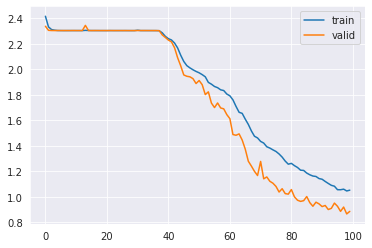

```python
# Capturing learning history per epoch
hist  = pd.DataFrame(history2.history)
hist['epoch'] = history2.epoch

# Plotting accuracy at different epochs
plt.plot(hist['loss'])
plt.plot(hist['val_loss'])
plt.legend(("train" , "valid") , loc =0)

# Printing results
results = model2.evaluate(X_test, y_test)
```

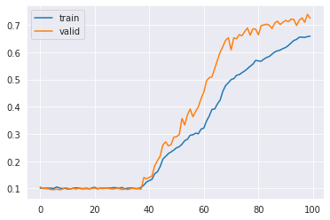

```python
# Capturing learning history per epoch
hist  = pd.DataFrame(history2.history)
hist['epoch'] = history2.epoch

# Plotting accuracy at different epochs
plt.plot(hist['accuracy'])
plt.plot(hist['val_accuracy'])
plt.legend(("train" , "valid") , loc =0)

# Printing results
results = model2.evaluate(X_test, y_test)
```

```
Loss and Accuracy on Training data: [0.827132523059845, 0.7416190505027771]
Loss and Accuracy on Test data: [0.8844013810157776, 0.7257221937179565]

Classification Report:
               precision    recall  f1-score   support

           0       0.81      0.74      0.77      1814
           1       0.74      0.79      0.76      1828
           2       0.83      0.71      0.76      1803
           3       0.57      0.74      0.64      1719
           4       0.83      0.77      0.80      1812
           5       0.60      0.71      0.65      1768
           6       0.78      0.70      0.74      1832
           7       0.77      0.77      0.77      1808
           8       0.72      0.66      0.69      1812
           9       0.69      0.69      0.69      1804

    accuracy                           0.73     18000
   macro avg       0.73      0.73      0.73     18000
weighted avg       0.74      0.73      0.73     18000

Confusion Matrix Chart:
```

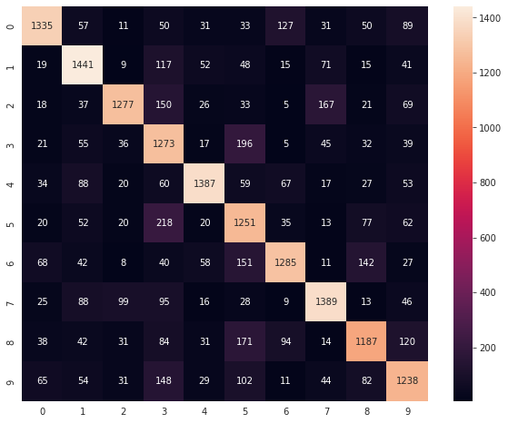

```python
# Classification Accuracy
print('Loss and Accuracy on Training data:',model2.evaluate(X_train, y_train))
print('Loss and Accuracy on Test data:',model2.evaluate(X_test, y_test))
print()

# Classification Report
print("Classification Report:\n",classification_report(y_test.values.argmax(axis=1), y_pred.argmax(axis=1)))

# Confusion Matrix
print("Confusion Matrix Chart:")
cm = confusion_matrix(y_test.values.argmax(axis=1), y_pred.argmax(axis=1), labels=[0,1,2,3,4,5,6,7,8,9])
df_cm = pd.DataFrame(cm, index = [i for i in ['0','1','2','3','4','5','6','7','8','9']],
                  columns = [i for i in ['0','1','2','3','4','5','6','7','8','9']])
plt.figure(figsize = (10,8))
sns.heatmap(df_cm, annot=True, fmt='g')
plt.show()
```

### Model-3: Using Hyperparameter Tuning

```python
import tensorflow as tf
from tensorflow.keras.models import Sequential
from tensorflow.keras.layers import Dense
from tensorflow.keras.layers import Dense, Input, Dropout, BatchNormalization
from tensorflow.keras.wrappers.scikit_learn import KerasClassifier
import random
from tensorflow.keras import backend
random.seed(1)
np.random.seed(1)
tf.random.set_seed(1)
```

```python
def create_model(lr,batch_size):
    model= Sequential()
    model.add(BatchNormalization(input_shape=((1024,))))
    model.add(Dense(256,activation='relu'))
    model.add(Dense(64,activation='relu'))
    model.add(Dense(32,activation='relu'))
    model.add(Dense(num_classes,activation='softmax'))
    # compile the model
    sgd = optimizers.Adam(learning_rate = lr)
    model.compile(loss=losses.categorical_crossentropy,optimizer=sgd,metrics=['accuracy'])
    return model
```

```python
model3 = KerasClassifier(build_fn=create_model, verbose=1)

params = {'batch_size':[32, 64, 128],
          'lr':[0.01,0.1,0.001]}

gs = RandomizedSearchCV(estimator=model3, param_distributions=params, cv=5, verbose=10, n_jobs=2, random_state=0)
gs.fit(X_train, y_train)
```

```
Fitting 5 folds for each of 9 candidates, totalling 45 fits
```

```
RandomizedSearchCV(cv=5,
                   estimator=<keras.wrappers.scikit_learn.KerasClassifier object at 0x7f83fc96de90>,
                   n_jobs=2,
                   param_distributions={'batch_size': [32, 64, 128],
                                        'lr': [0.01, 0.1, 0.001]},
                   random_state=0, verbose=10)
```

```python
pd.DataFrame({'param': gs.cv_results_["params"],
              'score mean': gs.cv_results_["mean_test_score"],
              'score s.d.': gs.cv_results_["std_test_score"],
              'rank': gs.cv_results_["rank_test_score"]})
```

|  | param | score mean | score s.d. | rank |
| --- | --- | --- | --- | --- |
| 0 | {'lr': 0.01, 'batch_size': 32} | 0.140714 | 0.086110 | 5 |
| 1 | {'lr': 0.1, 'batch_size': 32} | 0.100024 | 0.003656 | 8 |
| 2 | {'lr': 0.001, 'batch_size': 32} | 0.647048 | 0.021869 | 3 |
| 3 | {'lr': 0.01, 'batch_size': 64} | 0.167500 | 0.042722 | 4 |
| 4 | {'lr': 0.1, 'batch_size': 64} | 0.100548 | 0.003506 | 7 |
| 5 | {'lr': 0.001, 'batch_size': 64} | 0.658333 | 0.005771 | 1 |
| 6 | {'lr': 0.01, 'batch_size': 128} | 0.110167 | 0.019519 | 6 |
| 7 | {'lr': 0.1, 'batch_size': 128} | 0.098619 | 0.003257 | 9 |
| 8 | {'lr': 0.001, 'batch_size': 128} | 0.648167 | 0.013233 | 2 |

```python
print('Best Parameters:', gs.best_params_, 'mean score: ', gs.best_score_, sep='\n')
```

```
Best Parameters:
{'lr': 0.001, 'batch_size': 64}
mean score:
0.6583333373069763
```

```python
model3=create_model(batch_size=64, lr=0.001)

model3.summary()
```

```
Model: "sequential_3"
_________________________________________________________________
 Layer (type)                Output Shape              Param #
=================================================================
 batch_normalization_2 (Batc  (None, 1024)             4096
 hNormalization)

 dense_14 (Dense)            (None, 256)               262400

 dense_15 (Dense)            (None, 64)                16448

 dense_16 (Dense)            (None, 32)                2080

 dense_17 (Dense)            (None, 10)                330

=================================================================
Total params: 285,354
Trainable params: 283,306
Non-trainable params: 2,048
_________________________________________________________________
```

```python
optimizer = tf.keras.optimizers.Adam(0.001)
model3.compile(loss='categorical_crossentropy',optimizer=optimizer,metrics=['accuracy'])

history3=model3.fit(X_train, y_train, epochs=50, batch_size = 200, verbose=1, validation_split=0.2)
```

```python
# predicting the model1 on test data
y_pred=model3.predict(X_test)
```

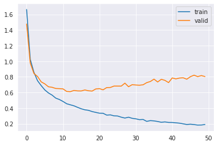

```python
# Capturing learning history3 per epoch
hist  = pd.DataFrame(history3.history)
hist['epoch'] = history3.epoch

# Plotting accuracy at different epochs
plt.plot(hist['loss'])
plt.plot(hist['val_loss'])
plt.legend(("train" , "valid") , loc =0)

# Printing results
results = model3.evaluate(X_test, y_test)
```

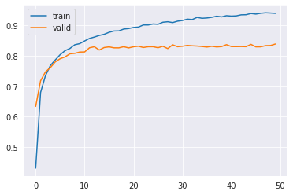

```python
# Capturing learning history3 per epoch
hist  = pd.DataFrame(history3.history)
hist['epoch'] = history3.epoch

# Plotting accuracy at different epochs
plt.plot(hist['accuracy'])
plt.plot(hist['val_accuracy'])
plt.legend(("train" , "valid") , loc =0)

# Printing results
results = model3.evaluate(X_test, y_test)
```

```
Loss and Accuracy on Training data: [0.266448974609375, 0.9352856874465942]
Loss and Accuracy on Test data: [0.8015639185905457, 0.8364999890327454]

Classification Report:
               precision    recall  f1-score   support

           0       0.84      0.87      0.85      1814
           1       0.81      0.87      0.84      1828
           2       0.88      0.86      0.87      1803
           3       0.80      0.79      0.80      1719
           4       0.87      0.86      0.87      1812
           5       0.82      0.81      0.82      1768
           6       0.81      0.84      0.82      1832
           7       0.89      0.87      0.88      1808
           8       0.86      0.77      0.81      1812
           9       0.80      0.82      0.81      1804

    accuracy                           0.84     18000
   macro avg       0.84      0.84      0.84     18000
weighted avg       0.84      0.84      0.84     18000

Confusion Matrix Chart:
```

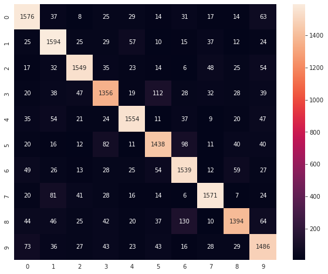

```python
# Classification Accuracy
print('Loss and Accuracy on Training data:',model3.evaluate(X_train, y_train))
print('Loss and Accuracy on Test data:',model3.evaluate(X_test, y_test))
print()

# Classification Report
print("Classification Report:\n",classification_report(y_test.values.argmax(axis=1), y_pred.argmax(axis=1)))

# Confusion Matrix
print("Confusion Matrix Chart:")
cm = confusion_matrix(y_test.values.argmax(axis=1), y_pred.argmax(axis=1), labels=[0,1,2,3,4,5,6,7,8,9])
df_cm = pd.DataFrame(cm, index = [i for i in ['0','1','2','3','4','5','6','7','8','9']],
                  columns = [i for i in ['0','1','2','3','4','5','6','7','8','9']])
plt.figure(figsize = (10,8))
sns.heatmap(df_cm, annot=True, fmt='g')
plt.show()
```